# Exp1 Online- StandardAnalysis

Mrudula & Carina

25/08/2020

### Fundamentals

The datafiles from 60 participants were collected from pavlovia via prolific. All the data files have been combined together to one datafile. This datafile is loaded along with the necessary libraries needed for the data preparation/cleaning and analysis.

### Cleaning the datafile

To arrive at a clean datafile, certain columns are removed such as columns containing details with instructions, pauses attention Check, etc.

The column containing the RTs is split because some rows contain more than one RT because the psychopy is designed in such a way that only upon the correct answer the next trial is presented. So in trials that are incorrect there will be more than one RT value registered. However we are only interested in the first response, hence the RT column is split to contain the first response time in a separate column. RTs should also be changed to double as they are represented as strings initially (with the presence of commas and square brackets)

These RT values are further edited:

- Psychopy originally evaluated the RTs from 400ms irrespective of the PreTrial Display time
- Hence, to the RT value, 400ms is added and later subtracted by the PreTrialDisplay time(also includes fixation cross) (in ms) for each trial

##### Data Preparation

Since the data is now cleaned to an extent, the next steps involve preparing the df

- Clearly identify the ACC and RT columns
- New column with error rate
- Removing the **practice trials and learn trials**
- Remove AttentionCheck

### Descriptive Statistics

The descriptive statistics of the sample are listed below

Descriptive Statistics of Sample Age

| Min. | 1st Qu. | Median | Mean | 3rd Qu. | Max. |
| --- | --- | --- | --- | --- | --- |
| 18 | 25 | 29 | 31.3 | 35.25 | 63 |

Number of participants per Age (continued below)

| 18 | 20 | 21 | 22 | 23 | 24 | 25 | 26 | 27 |
| --- | --- | --- | --- | --- | --- | --- | --- | --- |
| 6.05 | 2.017 | 4.033 | 4.033 | 6.05 | 4.033 | 6.05 | 12.1 | 2.017 |

Table continues below

| 28 | 29 | 30 | 31 | 32 | 33 | 34 | 35 | 36 |
| --- | --- | --- | --- | --- | --- | --- | --- | --- |
| 4.033 | 12.1 | 4.033 | 2.017 | 2.017 | 8.067 | 2.017 | 10.08 | 6.05 |

| 37 | 38 | 39 | 40 | 43 | 50 | 54 | 60 | 63 |
| --- | --- | --- | --- | --- | --- | --- | --- | --- |
| 4.033 | 2.017 | 2.017 | 6.05 | 2.017 | 2.017 | 2.017 | 2.017 | 2.017 |

Gender count

| female | male | other |
| --- | --- | --- |
| 42.35 | 74.62 | 4.033 |

Screen background colour across participants

| black | white |
| --- | --- |
| 64.53 | 56.47 |

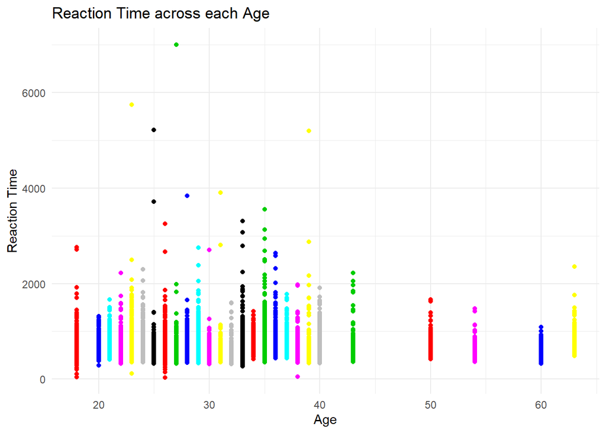

Summary of RT

| Min. | 1st Qu. | Median | Mean | 3rd Qu. | Max. |
| --- | --- | --- | --- | --- | --- |
| 35.19 | 489.4 | 557 | 595.1 | 643.9 | 7007 |

Number of correct and Incorrect trials

| 0 | 1 |
| --- | --- |
| 1364 | 27676 |

Percentage of errors

| 0 | 1 |
| --- | --- |
| 4.697 | 95.3 |

Exploring the data trends by comparing the fast and slow participants based on age

```r
aggMeanpp <- aggregate(data = Exp1data_OL, RT_Trials ~ participant, mean)
aggMeanpp <- aggMeanpp %>%
  dplyr::rename("MeanRT"  = "RT_Trials")

summary(aggMeanpp$MeanRT)
```

```
##    Min. 1st Qu.  Median    Mean 3rd Qu.    Max.
##   460.8   547.7   579.9   595.1   641.0   820.4
```

```r
#Splitting the participants at the median
aggMeanpp$Fastpar <- ifelse(aggMeanpp$MeanRT <= 579.9,1,0)
table(aggMeanpp$Fastpar)
```

```
##
##  0  1
## 30 30
```

```r
#combining these columns with the main df
Exp1data_OL <- merge(Exp1data_OL,aggMeanpp,by="participant")

Exp1data_OL$agerange <- ifelse(Exp1data_OL$Age <= 29, "Young", "Old")
```

### Removing Outliers and Farouts

Outliers and Farouts are identified at the individual level and the respective RT columns are created : One for outliers (RT_io) and one for Farouts (RT_ifo)

Summary of RT after removing Farouts

| Min. | 1st Qu. | Median | Mean | 3rd Qu. | Max. | NA’s |
| --- | --- | --- | --- | --- | --- | --- |
| 300.4 | 490.6 | 556.3 | 581.4 | 638.1 | 1619 | 1906 |

Summary of RT after removing Outliers

| Min. | 1st Qu. | Median | Mean | 3rd Qu. | Max. | NA’s |
| --- | --- | --- | --- | --- | --- | --- |
| 300.4 | 488.2 | 552.9 | 568.1 | 626.8 | 1245 | 2874 |

#### Analysis on the types of participants and how they differed across conditions: learn/test

```r
#Checking the performances on learn and test trials for fast and slow pps
aggCond <- aggregate(data = Exp1data_OL, RT_ifo~participant+Condition+Fastpar, mean)

aggCond$participant <- as.factor(aggCond$participant)
aggCond$Condition <- as.factor(aggCond$Condition)
aggCond$Fastpar <- as.factor(aggCond$Fastpar)

abcanova <- ezANOVA(data=aggCond,
                    dv = RT_ifo,
                    wid = participant,
                    within = .(Condition),
                    between = .(Fastpar),
                    detailed = TRUE)
anova_out(abcanova)
```

```
## $`--- ANOVA RESULTS     ------------------------------------`
##              Effect        MSE df1 df2       F     p petasq getasq
## 1       (Intercept) 4428.76443   1  58 9131.27 0.000   0.99   0.99
## 2           Fastpar 4428.76443   1  58   81.32 0.000   0.58   0.58
## 3         Condition   60.42371   1  58    2.21 0.143   0.04   0.00
## 4 Fastpar:Condition   60.42371   1  58    1.77 0.189   0.03   0.00
##
## $`--- SPHERICITY TESTS  ------------------------------------`
## [1] "N/A"
##
## $`--- FORMATTED RESULTS ------------------------------------`
##              Effect                                    Text
## 1       (Intercept) F(1, 58) = 9131.27, p < .001, np2 = .99
## 2           Fastpar F(1, 58) =   81.32, p < .001, np2 = .58
## 3         Condition F(1, 58) =    2.21, p = .143, np2 = .04
## 4 Fastpar:Condition F(1, 58) =    1.77, p = .189, np2 = .03
##
## $`NOTE:`
## [1] "Reporting unadjusted p-values."
```

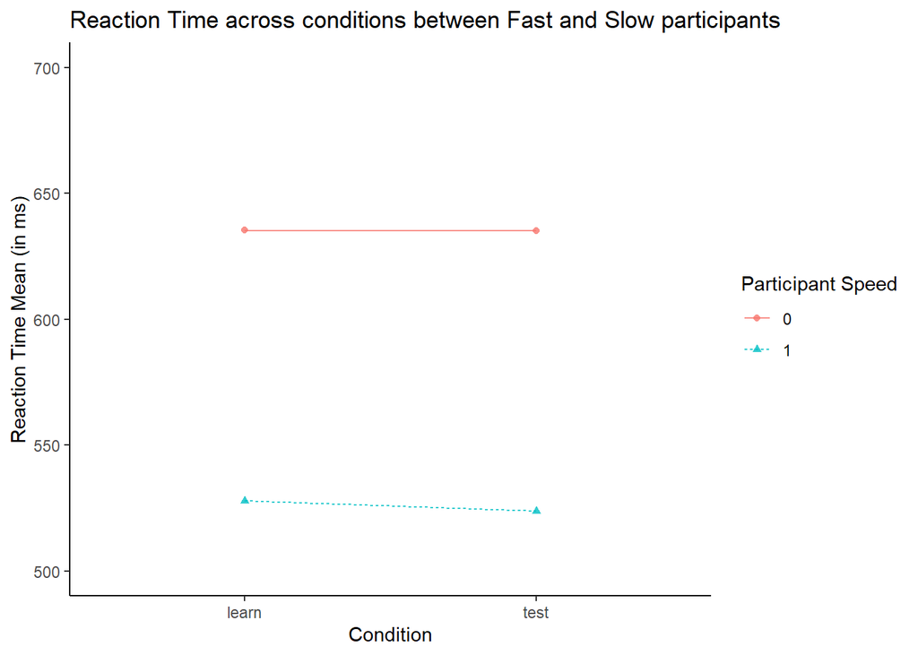

```r
ezPlot(data=aggCond,
       dv = RT_ifo,
       wid = participant,
       within = .(Condition),
       between = .(Fastpar),
       x=Condition,
       split = Fastpar,
       y_lab = "Reaction Time Mean (in ms)",
       split_lab = "Participant Speed",
       do_bars = FALSE)+
  theme_classic()+
  ylim(500,700)+
  ggtitle("Reaction Time across conditions between Fast and Slow participants")
```

## **STATISTICAL ANALYSIS**

Only the test trials are used for analysis. The following analyses are carried out separately for outliers and for farouts

#### **Aggregate means for Standard Analysis : RT with Validity and Saliency as factors**

Aggregate means for the Standard Analysis are computed along with the average of that which is used for plotting

#### **Aggregate means for Standard Analysis : ErrorRate with Validity and Saliency as factors**

Aggregate ErrorRate was also calculated across each participant

## *ANOVA & PLOTS*

### 1. Standard Analysis ANOVA with plot: FAROUTS removed

```r
#using EzANOVA
standard_anova_fo <- ezANOVA(data=Exp1agg_Standard_fo,
                    dv = RT_ifo,
                    wid = participant,
                    within = .(Sal,Val),
                    type = 3,
                    detailed = TRUE)
anova_out(standard_anova_fo)
```

```
## $`--- ANOVA RESULTS     ------------------------------------`
##        Effect        MSE df1 df2       F     p petasq getasq
## 1 (Intercept) 21485.6098   1  59 3750.76 0.000   0.98   0.98
## 2         Sal   197.4958   1  59    0.05 0.816   0.00   0.00
## 3         Val   202.7506   1  59    0.11 0.744   0.00   0.00
## 4     Sal:Val   297.0224   1  59    1.41 0.240   0.02   0.00
##
## $`--- SPHERICITY TESTS  ------------------------------------`
## [1] "N/A"
##
## $`--- FORMATTED RESULTS ------------------------------------`
##        Effect                                    Text
## 1 (Intercept) F(1, 59) = 3750.76, p < .001, np2 = .98
## 2         Sal F(1, 59) =    0.05, p = .816, np2 < .01
## 3         Val F(1, 59) =    0.11, p = .744, np2 < .01
## 4     Sal:Val F(1, 59) =    1.41, p = .240, np2 = .02
##
## $`NOTE:`
## [1] "Reporting unadjusted p-values."
```

```r
#using aov (matching with ez)
# standard_anova_fo <- aov(RT_ifo~(Val*Sal)+ Error(participant/1), data = Exp1agg_Standard_fo)


# panderOptions('table.split.table',300)
pander(standard_anova_fo, style = 'rmarkdown', caption = "Standard ANOVA table: RT(farouts) as a function of Saliency and Validity", split.table = Inf, missing = NA)
```

- **ANOVA**:

  Table continues below

  | Effect | DFn | DFd | SSn | SSd | F | p | p<.05 |
  | --- | --- | --- | --- | --- | --- | --- | --- |
  | (Intercept) | 1 | 59 | 80587260 | 1267651 | 3751 | 4.184e-55 | * |
  | Sal | 1 | 59 | 10.85 | 11652 | 0.05492 | 0.8155 |  |
  | Val | 1 | 59 | 21.77 | 11962 | 0.1074 | 0.7443 |  |
  | Sal:Val | 1 | 59 | 417.6 | 17524 | 1.406 | 0.2405 |  |

  | ges |
  | --- |
  | 0.984 |
  | 8.287e-06 |
  | 1.664e-05 |
  | 0.000319 |

### 2. Standard Analysis ANOVA with plot: Outliers removed

```r
#outliers
#with ez

standard_anova_o <- ezANOVA(data=Exp1agg_Standard_o,
                    dv = RT_io,
                    wid = participant,
                    within = .(Sal,Val),
                    detailed = TRUE)
anova_out(standard_anova_o)
```

```
## $`--- ANOVA RESULTS     ------------------------------------`
##        Effect        MSE df1 df2       F     p petasq getasq
## 1 (Intercept) 18769.2852   1  59 4114.38 0.000   0.99   0.99
## 2         Sal   139.5608   1  59    0.03 0.858   0.00   0.00
## 3         Val   140.2357   1  59    1.33 0.253   0.02   0.00
## 4     Sal:Val   184.9455   1  59    0.45 0.505   0.01   0.00
##
## $`--- SPHERICITY TESTS  ------------------------------------`
## [1] "N/A"
##
## $`--- FORMATTED RESULTS ------------------------------------`
##        Effect                                    Text
## 1 (Intercept) F(1, 59) = 4114.38, p < .001, np2 = .99
## 2         Sal F(1, 59) =    0.03, p = .858, np2 < .01
## 3         Val F(1, 59) =    1.33, p = .253, np2 = .02
## 4     Sal:Val F(1, 59) =    0.45, p = .505, np2 = .01
##
## $`NOTE:`
## [1] "Reporting unadjusted p-values."
```

```r
# standard_anova_o <- aov(RT_io~(Val*Sal)+Error(participant/(Val*Sal)), data = Exp1agg_Standard_o)

panderOptions('table.split.table',300)
pander(standard_anova_o, style = 'rmarkdown', caption = "Standard ANOVA table: RT(outliers) as a function of Saliency and Validity", split.table = Inf)
```

- **ANOVA**:

  | Effect | DFn | DFd | SSn | SSd | F | p | p<.05 | ges |
  | --- | --- | --- | --- | --- | --- | --- | --- | --- |
  | (Intercept) | 1 | 59 | 77223947 | 1107388 | 4114 | 2.841e-56 | * | 0.9855 |
  | Sal | 1 | 59 | 4.509 | 8234 | 0.03231 | 0.858 |  | 3.973e-06 |
  | Val | 1 | 59 | 186.8 | 8274 | 1.332 | 0.253 |  | 0.0001646 |
  | Sal:Val | 1 | 59 | 83.22 | 10912 | 0.45 | 0.505 |  | 7.333e-05 |

### 3. Standard Analysis with Error Rate

Standard ANOVA table: Error Rates as a function of Saliency and Validity #### Plot showing the Error rate for valid and Salient Trials

|  | Df | Sum Sq | Mean Sq | F value | Pr(>F) |
| --- | --- | --- | --- | --- | --- |
| **Residuals** | 59 | 2815 | 47.7 | NA | NA |
| **Validity** | 1 | 16.71 | 16.71 | 2.785 | 0.1005 |
| **Residuals1** | 59 | 354.1 | 6.002 | NA | NA |
| **Saliency** | 1 | 0.1852 | 0.1852 | 0.01418 | 0.9056 |
| **Residuals2** | 59 | 770.6 | 13.06 | NA | NA |
| **Validity:Saliency** | 1 | 5.602 | 5.602 | 0.9714 | 0.3283 |
| **Residuals** | 59 | 340.2 | 5.767 | NA | NA |

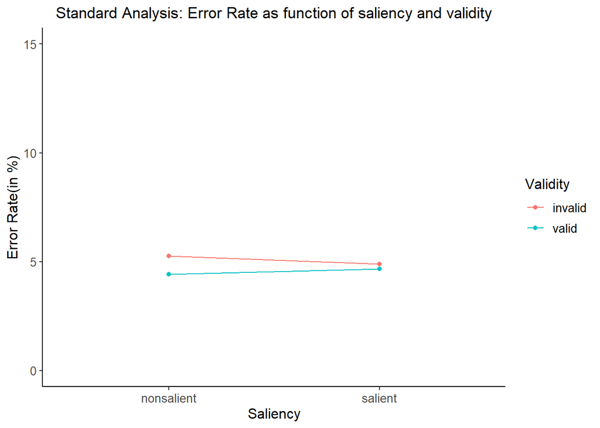

## 4. Block analysis

#### Farouts

Standard ANOVA table: RT as a function of Saliency and Validity and Block Plot showing the RT mean with the function of validity and Saliency across the Blocks

|  | Df | Sum Sq | Mean Sq | F value | Pr(>F) |
| --- | --- | --- | --- | --- | --- |
| **Residuals** | 59 | 3814995 | 64661 | NA | NA |
| **Val** | 1 | 132.1 | 132.1 | 0.2167 | 0.6433 |
| **Residuals1** | 59 | 35982 | 609.9 | NA | NA |
| **Sal** | 1 | 33.95 | 33.95 | 0.05545 | 0.8147 |
| **Residuals2** | 59 | 36127 | 612.3 | NA | NA |
| **BlockCount** | 2 | 45503 | 22752 | 11.89 | 1.978e-05 |
| **Residuals** | 118 | 225818 | 1914 | NA | NA |
| **Val:Sal** | 1 | 1442 | 1442 | 1.675 | 0.2007 |
| **Residuals3** | 59 | 50792 | 860.9 | NA | NA |
| **Val:BlockCount** | 2 | 150.4 | 75.22 | 0.1096 | 0.8962 |
| **Residuals** | 118 | 80953 | 686 | NA | NA |
| **Sal:BlockCount** | 2 | 313.6 | 156.8 | 0.2178 | 0.8046 |
| **Residuals 1** | 118 | 84931 | 719.8 | NA | NA |
| **Val:Sal:BlockCount** | 2 | 1364 | 681.8 | 1.169 | 0.3143 |
| **Residuals** | 118 | 68839 | 583.4 | NA | NA |

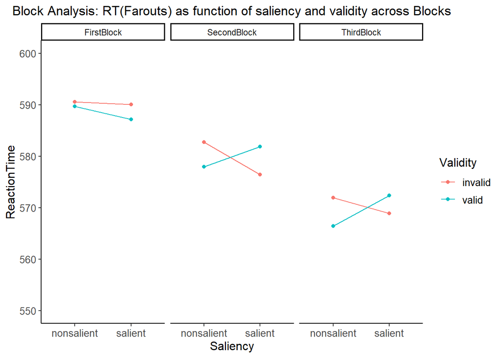

#### Outliers

Standard ANOVA table: RT(outliers removed) as a function of Saliency and Validity and Block

|  | Df | Sum Sq | Mean Sq | F value | Pr(>F) |
| --- | --- | --- | --- | --- | --- |
| **Residuals** | 59 | 3325346 | 56362 | NA | NA |
| **Val** | 1 | 622.8 | 622.8 | 1.48 | 0.2286 |
| **Residuals1** | 59 | 24820 | 420.7 | NA | NA |
| **Sal** | 1 | 14.24 | 14.24 | 0.03285 | 0.8568 |
| **Residuals2** | 59 | 25569 | 433.4 | NA | NA |
| **BlockCount** | 2 | 31037 | 15518 | 11.56 | 2.607e-05 |
| **Residuals** | 118 | 158438 | 1343 | NA | NA |
| **Val:Sal** | 1 | 400.6 | 400.6 | 0.7795 | 0.3809 |
| **Residuals3** | 59 | 30321 | 513.9 | NA | NA |
| **Val:BlockCount** | 2 | 243.3 | 121.7 | 0.2493 | 0.7797 |
| **Residuals** | 118 | 57584 | 488 | NA | NA |
| **Sal:BlockCount** | 2 | 1398 | 699.2 | 1.389 | 0.2534 |
| **Residuals 1** | 118 | 59404 | 503.4 | NA | NA |
| **Val:Sal:BlockCount** | 2 | 3011 | 1505 | 3.773 | 0.0258 |
| **Residuals** | 118 | 47078 | 399 | NA | NA |

**Plot showing the mean RT with Validity and Saliency as factors across each block**

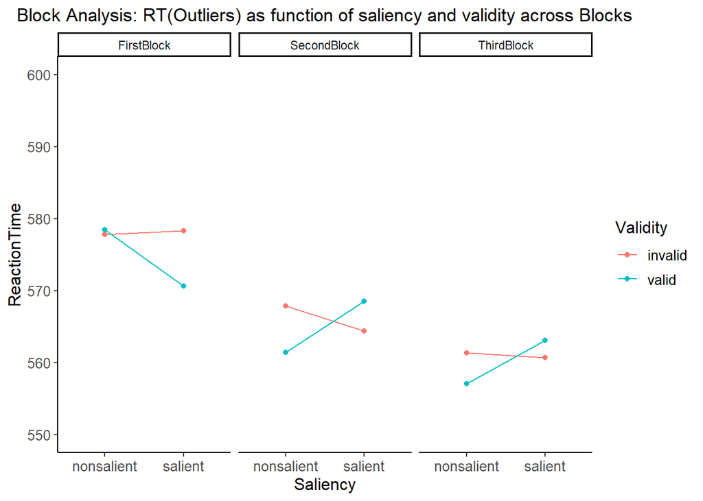

### Between participants comparison

```r
Exp1agg_StdPP_fo <- aggregate(data = Exp1data_OL, RT_ifo~participant+Saliency+Validity+Fastpar, mean)

#convert to factors for ANOVA
Exp1agg_StdPP_fo$participant <- as.factor(Exp1agg_StdPP_fo$participant)
Exp1agg_StdPP_fo$Saliency <- as.factor(Exp1agg_StdPP_fo$Saliency)
Exp1agg_StdPP_fo$Validity <- as.factor(Exp1agg_StdPP_fo$Validity)

#creating two datsets for fast and slow pps
Fast <- subset(Exp1agg_StdPP_fo, subset = (Fastpar==1))

Slow <- subset(Exp1agg_StdPP_fo, subset = (Fastpar==0))

Exp1agg_StdPP_fo$Fastpar <- ifelse(Exp1agg_StdPP_fo$Fastpar == 1, "Fast", "Slow")


Exp1agg_StdPP_fo$Fastpar <- as.factor(Exp1agg_StdPP_fo$Fastpar)



#By adding the type of participant as between subjects factor, explore the data trend
stdanova_pp <- ezANOVA(data=Exp1agg_StdPP_fo,
                    dv = RT_ifo,
                    wid = participant,
                    within = .(Saliency,Validity),
                    between = .(Fastpar),
                    detailed = TRUE)
anova_out(stdanova_pp)
```

```
## $`--- ANOVA RESULTS     ------------------------------------`
##                      Effect       MSE df1 df2       F     p petasq getasq
## 1               (Intercept) 9015.4976   1  58 8938.75 0.000   0.99   0.99
## 2                   Fastpar 9015.4976   1  58   82.61 0.000   0.59   0.57
## 3                  Saliency  179.0094   1  58    0.06 0.806   0.00   0.00
## 4                  Validity  197.0217   1  58    0.11 0.741   0.00   0.00
## 5          Fastpar:Saliency  179.0094   1  58    7.09 0.010   0.11   0.00
## 6          Fastpar:Validity  197.0217   1  58    2.72 0.105   0.04   0.00
## 7         Saliency:Validity  293.5575   1  58    1.42 0.238   0.02   0.00
## 8 Fastpar:Saliency:Validity  293.5575   1  58    1.70 0.198   0.03   0.00
##
## $`--- SPHERICITY TESTS  ------------------------------------`
## [1] "N/A"
##
## $`--- FORMATTED RESULTS ------------------------------------`
##                      Effect                                    Text
## 1               (Intercept) F(1, 58) = 8938.75, p < .001, np2 = .99
## 2                   Fastpar F(1, 58) =   82.61, p < .001, np2 = .59
## 3                  Saliency F(1, 58) =    0.06, p = .806, np2 < .01
## 4                  Validity F(1, 58) =    0.11, p = .741, np2 < .01
## 5          Fastpar:Saliency F(1, 58) =    7.09, p = .010, np2 = .11
## 6          Fastpar:Validity F(1, 58) =    2.72, p = .105, np2 = .04
## 7         Saliency:Validity F(1, 58) =    1.42, p = .238, np2 = .02
## 8 Fastpar:Saliency:Validity F(1, 58) =    1.70, p = .198, np2 = .03
##
## $`NOTE:`
## [1] "Reporting unadjusted p-values."
```

```r
pander(stdanova_pp, style = 'rmarkdown', caption = "Standard ANOVA table: RT(farouts) as a function of Saliency and Validity between fast and slow participants", split.table = Inf)
```

- **ANOVA**:

  |  | Effect | DFn | DFd | SSn | SSd | F | p | p<.05 | ges |
  | --- | --- | --- | --- | --- | --- | --- | --- | --- | --- |
  | **1** | (Intercept) | 1 | 58 | 80587260 | 522899 | 8939 | 3.095e-65 | * | 0.9931 |
  | **2** | Fastpar | 1 | 58 | 744752 | 522899 | 82.61 | 9.463e-13 | * | 0.57 |
  | **3** | Saliency | 1 | 58 | 10.85 | 10383 | 0.06059 | 0.8064 |  | 1.931e-05 |
  | **5** | Validity | 1 | 58 | 21.77 | 11427 | 0.1105 | 0.7408 |  | 3.876e-05 |
  | **4** | Fastpar:Saliency | 1 | 58 | 1270 | 10383 | 7.093 | 0.01 | * | 0.002255 |
  | **6** | Fastpar:Validity | 1 | 58 | 535 | 11427 | 2.716 | 0.1048 |  | 0.0009515 |
  | **7** | Saliency:Validity | 1 | 58 | 417.6 | 17026 | 1.423 | 0.2378 |  | 0.0007429 |
  | **8** | Fastpar:Saliency:Validity | 1 | 58 | 498 | 17026 | 1.696 | 0.1979 |  | 0.0008857 |

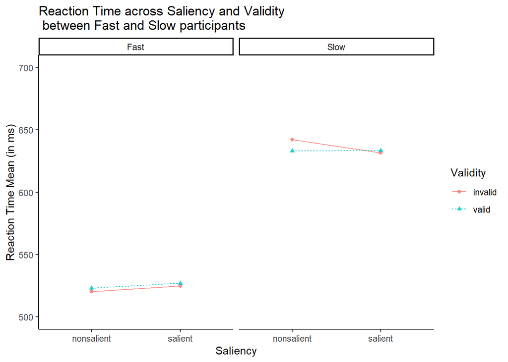

```r
ezPlot(data=Exp1agg_StdPP_fo,
       dv = RT_ifo,
       wid = participant,
       within = .(Saliency,Validity),
       between = .(Fastpar),
       x=Saliency, y_lab = "Reaction Time Mean (in ms)",
       split = Validity, col = Fastpar,do_bars = FALSE)+
  theme_classic()+
  ylim(500,700)+
  ggtitle("Reaction Time across Saliency and Validity \n between Fast and Slow participants")
```

```r
##outliers
Exp1agg_StdPP_o <- aggregate(data = Exp1data_OL, RT_io~participant+Saliency+Validity+Fastpar, mean)

#convert to factors for ANOVA
Exp1agg_StdPP_o$participant <- as.factor(Exp1agg_StdPP_o$participant)
Exp1agg_StdPP_o$Saliency <- as.factor(Exp1agg_StdPP_o$Saliency)
Exp1agg_StdPP_o$Validity <- as.factor(Exp1agg_StdPP_o$Validity)


Exp1agg_StdPP_o$Fastpar <- ifelse(Exp1agg_StdPP_o$Fastpar == 1, "Fast", "Slow")


Exp1agg_StdPP_o$Fastpar <- as.factor(Exp1agg_StdPP_o$Fastpar)

#By adding the type of participant as between subjects factor, explore the data trend
stdanova_pp_o <- ezANOVA(data=Exp1agg_StdPP_o,
                    dv = RT_io,
                    wid = participant,
                    within = .(Saliency,Validity),
                    between = .(Fastpar),
                    detailed = TRUE)
anova_out(stdanova_pp_o)
```

```
## $`--- ANOVA RESULTS     ------------------------------------`
##                      Effect       MSE df1 df2       F     p petasq getasq
## 1               (Intercept) 7744.3880   1  58 9971.60 0.000   0.99   0.99
## 2                   Fastpar 7744.3880   1  58   84.99 0.000   0.59   0.58
## 3                  Saliency  137.6975   1  58    0.03 0.857   0.00   0.00
## 4                  Validity  126.9518   1  58    1.47 0.230   0.02   0.00
## 5          Fastpar:Saliency  137.6975   1  58    1.80 0.185   0.03   0.00
## 6          Fastpar:Validity  126.9518   1  58    7.17 0.010   0.11   0.00
## 7         Saliency:Validity  181.4680   1  58    0.46 0.501   0.01   0.00
## 8 Fastpar:Saliency:Validity  181.4680   1  58    2.13 0.150   0.04   0.00
##
## $`--- SPHERICITY TESTS  ------------------------------------`
## [1] "N/A"
##
## $`--- FORMATTED RESULTS ------------------------------------`
##                      Effect                                    Text
## 1               (Intercept) F(1, 58) = 9971.60, p < .001, np2 = .99
## 2                   Fastpar F(1, 58) =   84.99, p < .001, np2 = .59
## 3                  Saliency F(1, 58) =    0.03, p = .857, np2 < .01
## 4                  Validity F(1, 58) =    1.47, p = .230, np2 = .02
## 5          Fastpar:Saliency F(1, 58) =    1.80, p = .185, np2 = .03
## 6          Fastpar:Validity F(1, 58) =    7.17, p = .010, np2 = .11
## 7         Saliency:Validity F(1, 58) =    0.46, p = .501, np2 = .01
## 8 Fastpar:Saliency:Validity F(1, 58) =    2.13, p = .150, np2 = .04
##
## $`NOTE:`
## [1] "Reporting unadjusted p-values."
```

```r
pander(stdanova_pp_o, style = 'rmarkdown', caption = "Standard ANOVA table: RT(outliers) as a function of Saliency and Validity between fast and slow participants", split.table = Inf)
```

- **ANOVA**:

  |  | Effect | DFn | DFd | SSn | SSd | F | p | p<.05 | ges |
  | --- | --- | --- | --- | --- | --- | --- | --- | --- | --- |
  | **1** | (Intercept) | 1 | 58 | 77223947 | 449175 | 9972 | 1.324e-66 | * | 0.9939 |
  | **2** | Fastpar | 1 | 58 | 658213 | 449175 | 84.99 | 5.779e-13 | * | 0.5808 |
  | **3** | Saliency | 1 | 58 | 4.509 | 7986 | 0.03274 | 0.857 |  | 9.491e-06 |
  | **5** | Validity | 1 | 58 | 186.8 | 7363 | 1.472 | 0.23 |  | 0.0003932 |
  | **4** | Fastpar:Saliency | 1 | 58 | 247.6 | 7986 | 1.798 | 0.1851 |  | 0.000521 |
  | **6** | Fastpar:Validity | 1 | 58 | 910.7 | 7363 | 7.174 | 0.009609 | * | 0.001913 |
  | **7** | Saliency:Validity | 1 | 58 | 83.22 | 10525 | 0.4586 | 0.501 |  | 0.0001752 |
  | **8** | Fastpar:Saliency:Validity | 1 | 58 | 386.6 | 10525 | 2.131 | 0.1498 |  | 0.0008132 |

```r
Fastanova <- ezANOVA(data=Fast,
                    dv = RT_ifo,
                    wid = participant,
                    within = .(Saliency,Validity),
                    detailed = TRUE)
anova_out(Fastanova)
```

```
## $`--- ANOVA RESULTS     ------------------------------------`
##              Effect       MSE df1 df2       F     p petasq getasq
## 1       (Intercept) 4097.2815   1  29 8034.33 0.000   1.00   1.00
## 2          Saliency  163.2233   1  29    3.20 0.084   0.10   0.00
## 3          Validity  147.3012   1  29    1.16 0.291   0.04   0.00
## 4 Saliency:Validity  173.9221   1  29    0.01 0.920   0.00   0.00
##
## $`--- SPHERICITY TESTS  ------------------------------------`
## [1] "N/A"
##
## $`--- FORMATTED RESULTS ------------------------------------`
##              Effect                                    Text
## 1       (Intercept) F(1, 29) = 8034.33, p < .001, np2 > .99
## 2          Saliency F(1, 29) =    3.20, p = .084, np2 = .10
## 3          Validity F(1, 29) =    1.16, p = .291, np2 = .04
## 4 Saliency:Validity F(1, 29) =    0.01, p = .920, np2 < .01
##
## $`NOTE:`
## [1] "Reporting unadjusted p-values."
```

```r
Slowanova <- ezANOVA(data=Slow,
                    dv = RT_ifo,
                    wid = participant,
                    within = .(Saliency,Validity),
                    detailed = TRUE)
anova_out(Slowanova)
```

```
## $`--- ANOVA RESULTS     ------------------------------------`
##              Effect        MSE df1 df2       F     p petasq getasq
## 1       (Intercept) 13933.7137   1  29 3474.53 0.000   0.99   0.99
## 2          Saliency   194.7956   1  29    3.89 0.058   0.12   0.00
## 3          Validity   246.7422   1  29    1.57 0.221   0.05   0.00
## 4 Saliency:Validity   413.1928   1  29    2.21 0.148   0.07   0.00
##
## $`--- SPHERICITY TESTS  ------------------------------------`
## [1] "N/A"
##
## $`--- FORMATTED RESULTS ------------------------------------`
##              Effect                                    Text
## 1       (Intercept) F(1, 29) = 3474.53, p < .001, np2 = .99
## 2          Saliency F(1, 29) =    3.89, p = .058, np2 = .12
## 3          Validity F(1, 29) =    1.57, p = .221, np2 = .05
## 4 Saliency:Validity F(1, 29) =    2.21, p = .148, np2 = .07
##
## $`NOTE:`
## [1] "Reporting unadjusted p-values."
```

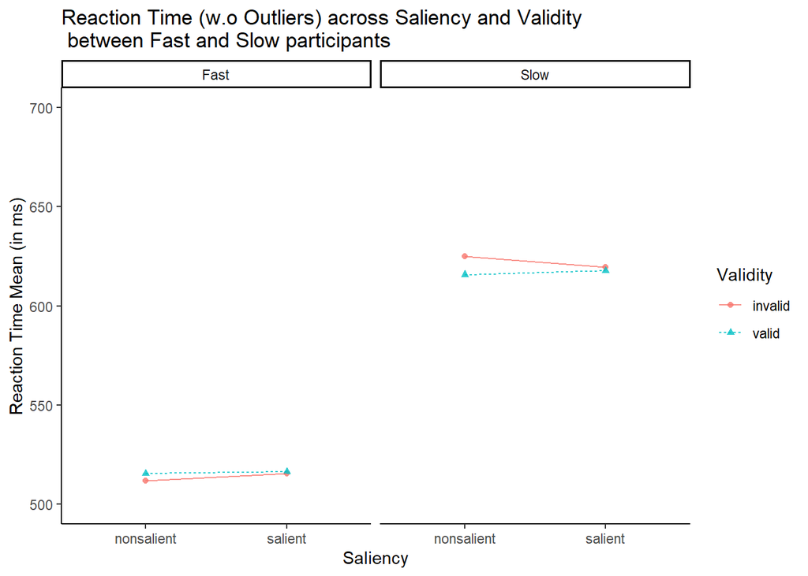

```r
ezPlot(data=Exp1agg_StdPP_o,
       dv = RT_io,
       wid = participant,
       within = .(Saliency,Validity),
       between = .(Fastpar),
       x=Saliency, y_lab = "Reaction Time Mean (in ms)",
       split = Validity, col = Fastpar,do_bars = FALSE)+
  theme_classic()+
  ylim(500,700)+
  ggtitle("Reaction Time (w.o Outliers) across Saliency and Validity \n between Fast and Slow participants")
```

## Exploratory Analysis

### 1. Age

No significant difference in the effect of validity or saliency in RT farouts and outliers

```r
#subsetting the dataframe to only include participants less than 35
Exp1data_OL_age <- Exp1data_OL%>%
  subset(Age <= 35)
#creating aggregate with farouts removed
Exp1agg_Age_fo <- aggregate(data = Exp1data_OL, RT_ifo~participant+Saliency+Validity+agerange, mean)

#to factors
Exp1agg_Age_fo$participant <- as.factor(Exp1agg_Age_fo$participant)
Exp1agg_Age_fo$Saliency <- as.factor(Exp1agg_Age_fo$Saliency)
Exp1agg_Age_fo$Validity <- as.factor(Exp1agg_Age_fo$Validity)
Exp1agg_Age_fo$agerange <- as.factor(Exp1agg_Age_fo$agerange)

#ANOVa
Age_anova_fo <- ezANOVA(Exp1agg_Age_fo,
                    dv = RT_ifo,
                    wid = participant,
                    within = .(Saliency,Validity),
                    between = .(agerange),
                    detailed = TRUE,
                    )
anova_out(Age_anova_fo)

ezPlot(data=Exp1agg_Age_fo,
       dv = RT_ifo,
       wid = participant,
       within = .(Saliency,Validity),
       between = .(agerange),
       x=Saliency, y_lab = "Reaction Time Mean (in ms)",
       split = Validity,col=agerange,do_bars = FALSE)+
 theme_classic()+
  ylim(500,700)+
  ggtitle("Reaction Time across Saliency and Validity \n among participants younger and older than 29")

##Same process for outliers
Exp1agg_Age_o <- aggregate(data = Exp1data_OL_age, RT_io~participant+Saliency+Validity, mean)

Exp1agg_Age_o$participant <- as.factor(Exp1agg_Age_o$participant)
Exp1agg_Age_o$Saliency <- as.factor(Exp1agg_Age_o$Saliency)
Exp1agg_Age_o$Validity <- as.factor(Exp1agg_Age_o$Validity)

Age_anova_o <- ezANOVA(Exp1agg_Age_o,
                    dv = RT_io,
                    wid = participant,
                    within = .(Saliency,Validity),
                    detailed = TRUE,
                    return_aov = TRUE)
anova_out(Age_anova_o)
```

#### 2. Bin Analysis

No difference in the bin analysis. It was done by splitting the RT as quartiles to cross check with the E-prime range

```r
#Splitting theRT distribution in quartiles to check whether the speed of RT shows differences in validity effect
#outliers
Exp1data_OL$Quantiles <- ntiles(Exp1data_OL,
                                dv = "RT_Trials",
                                bins = 4)

binagg <-  aggregate(data = Exp1data_OL, RT_ifo~participant+Saliency+Validity+Quantiles, mean)
binanova <- aov(RT_ifo~Validity+Quantiles+Saliency+Validity*Saliency, data = binagg)
summary(binanova)
meanbin <- ddply(binagg, .(Validity,Saliency,Quantiles), summarize, mean=mean(RT_ifo))
ggplot(meanbin, aes(x=Saliency, color=Validity, y=mean))+
  geom_line(aes(group=Validity))+
  geom_point()+
  labs(x="Saliency", y = "ReactionTime")+
  theme_classic()+
  facet_grid(.~Quantiles)+
  ggtitle("Standard Analysis: RT(Outliers) as function of saliency and validity")+
  theme(plot.title = element_text(hjust = 0.5))+
  theme(legend.title = element_text(size=12), legend.text= element_text(size=10))+
  theme(axis.title = element_text(size=12),axis.text = element_text(size=10))
```

#### 3. Speed Accuracy Tradeoff

#### 4. explore data: participants with many slow and/or erroneous resp?

#### 5. Word pair trends

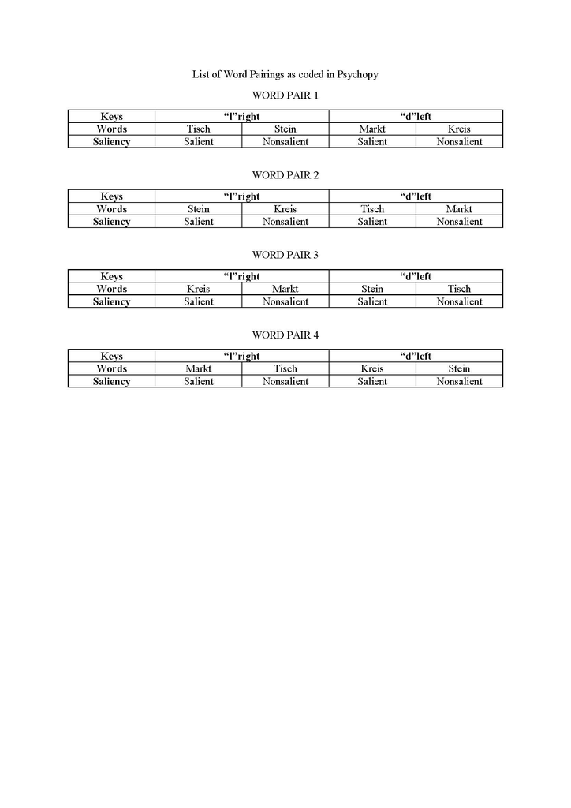

```r
include_graphics("D:/PhD/Exp1-Overshadowing/Exp/WORD PAIR Onlinestudy.jpg")
```

Points to be noted: This is the basic assignment given in the conditions.xlsx used in psychopy with the colour assignment of saliency based on white background So, this colour assignment was not counterbalanced based on screen background colour, and so for the black background, what was coded as salient, appeared as non salient since the colour was marked as dark grey (which is nonsalient on a black background).

This is also probably why there was a main effect of background colour in one of the earlier analyses.

This has been corrected below:

First is to create the aggregate based on word pair of the entire data set and to see how the data looks while analysing the entire data set across the factors of word pair, word too. There is a strong 3 way interaction between Distractor, Validity and Word pair indicating a possible effect of choice of word and validity

```r
wordagg <- aggregate(data=Exp1data_OL, RT_ifo~participant+Validity+Distractor1+Saliency+WordPair+CorrectAnswer, mean)


wordagg$participant <- as.factor(wordagg$participant)
wordagg$Validity <- as.factor(wordagg$Validity)
wordagg$Distractor1 <- as.factor(wordagg$Distractor1)
wordagg$Saliency <- as.factor(wordagg$Saliency)
wordagg$WordPair <- as.factor(wordagg$WordPair)
wordagg$CorrectAnswer <- as.factor(wordagg$CorrectAnswer)

wordanova <- ezANOVA(data = wordagg,
                     dv = RT_ifo,
                     wid = participant,
                     within = .(Validity, Distractor1),
                     between = .(WordPair),
                     detailed = TRUE)
anova_out(wordanova)
```

```
## $`--- ANOVA RESULTS     ------------------------------------`
##                          Effect        MSE df1 df2       F     p petasq
## 1                   (Intercept) 42598.1316   1  56 3783.91 0.000   0.99
## 2                      WordPair 42598.1316   3  56    1.18 0.324   0.06
## 3                      Validity   383.2946   1  56    0.06 0.808   0.00
## 4                   Distractor1   469.0894   3 168    0.11 0.954   0.00
## 5             WordPair:Validity   383.2946   3  56    1.86 0.148   0.09
## 6          WordPair:Distractor1   469.0894   9 168    1.00 0.445   0.05
## 7          Validity:Distractor1   738.5187   3 168    2.11 0.101   0.04
## 8 WordPair:Validity:Distractor1   738.5187   9 168    5.51 0.000   0.23
##   getasq
## 1   0.98
## 2   0.05
## 3   0.00
## 4   0.00
```

[output cut: 25 more lines]

```r
meanWordagg <- ddply(wordagg, .(Validity,Saliency,Distractor1,WordPair,CorrectAnswer), summarize, RTmean=mean(RT_ifo), SD = sd(RT_ifo))
# ezPlot(data = wordagg,
#        dv = RT_ifo,
#        wid = participant,
#        within = .(Validity,Distractor1),
#        between = .(WordPair),
#        x = Distractor1, split = Validity,col = WordPair, do_bars = FALSE)
```

Here is a plot that shows the Distribution of valid invalid trials for each word pair

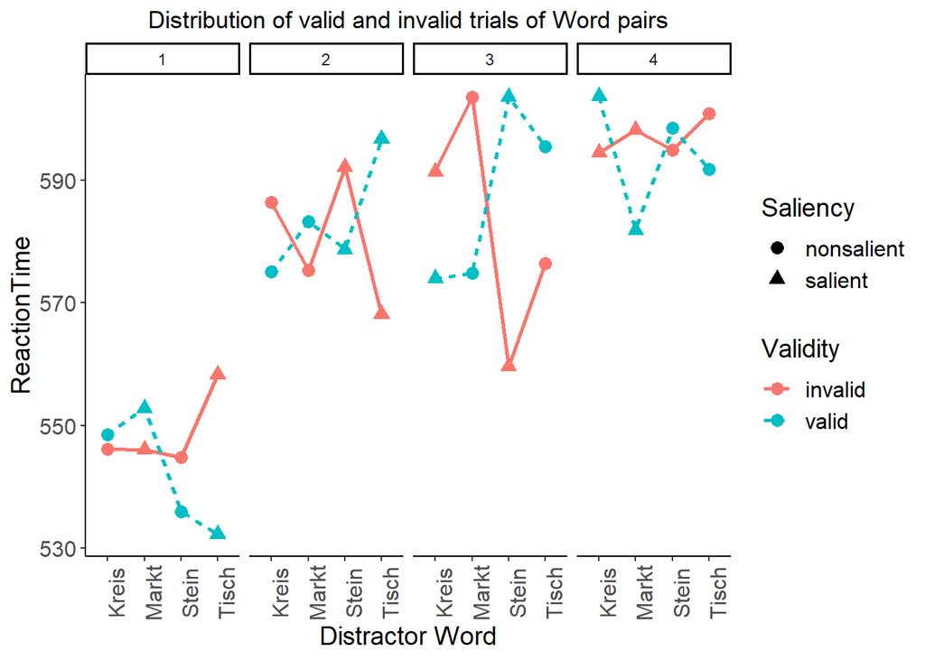

```r
wordpairplot <- ggplot(meanWordagg, aes(x=Distractor1, color=Validity, y=RTmean))+
  geom_line(aes(group=Validity, linetype = Validity), size = 1)+
  geom_point(aes(shape = Saliency), size = 3)+
  labs(x="Distractor Word", y = "ReactionTime", colour = "Validity", linetype = "Validity", shape = "Saliency")+
  facet_grid(~WordPair)+
  theme_classic()+
  # ylim(550,600)+
  ggtitle("Distribution of valid and invalid trials of Word pairs")+
  theme(plot.title = element_text(hjust = 0.5))+
  theme(legend.title = element_text(size=14), legend.text= element_text(size=12))+
  theme(axis.title = element_text(size=14),axis.text = element_text(size=12), axis.text.x = element_text(angle = 90))

#presenting the graph
wordpairplot
```

```r
#ggsave(wordpairplot, file = "Wordpairdistribution.jpeg", dpi = 800)
```

The plot shows the weird pattern where under each word pair combination (for eg., 1, 2 and so on), one of the word pairs of salient and non salient distractors had faster valid trials compared to invalid trials.

So to explore this further I split the data into people who had white background compared to people who had black background

### White Background

Here is the data concerning participants with white background: In other words, the participants where the saliency matched with what was coded, and what they saw. Like, Tisch if marked salient, also physically appeared salient in the experiment display

```
##
##   8   9  10  11  82 131 219 323 329 331 337 338 339 345 354 355 362 363
## 240 240 240 240 240 240 240 240 240 240 240 240 240 240 240 240 240 240
## 370 376 377 378 379 385 386 387 392 393
## 240 240 240 240 240 240 240 240 240 240
```

I computed the ANOVA to check for the data trends based on the true assignment and found that there is a significant interaction between Validity and Saliency.The interaction however is not in the expected direction, Still invalid salient trials are faster than valid salient trials

```r
Whitewordanova <- ezANOVA(data = wordWhitebg,
                     dv = RT_ifo,
                     wid = participant,
                     within = .(Validity, Saliency),
                     detailed = TRUE)
anova_out(Whitewordanova)
```

```
## $`--- ANOVA RESULTS     ------------------------------------`
##              Effect        MSE df1 df2       F     p petasq getasq
## 1       (Intercept) 12662.0876   1  27 2775.87 0.000   0.99   0.99
## 2          Validity   210.1749   1  27    0.02 0.887   0.00   0.00
## 3          Saliency   166.5101   1  27    0.14 0.713   0.01   0.00
## 4 Validity:Saliency   145.0436   1  27    5.10 0.032   0.16   0.00
##
## $`--- SPHERICITY TESTS  ------------------------------------`
## [1] "N/A"
##
## $`--- FORMATTED RESULTS ------------------------------------`
##              Effect                                    Text
## 1       (Intercept) F(1, 27) = 2775.87, p < .001, np2 = .99
## 2          Validity F(1, 27) =    0.02, p = .887, np2 < .01
## 3          Saliency F(1, 27) =    0.14, p = .713, np2 = .01
## 4 Validity:Saliency F(1, 27) =    5.10, p = .032, np2 = .16
##
## $`NOTE:`
## [1] "Reporting unadjusted p-values."
```

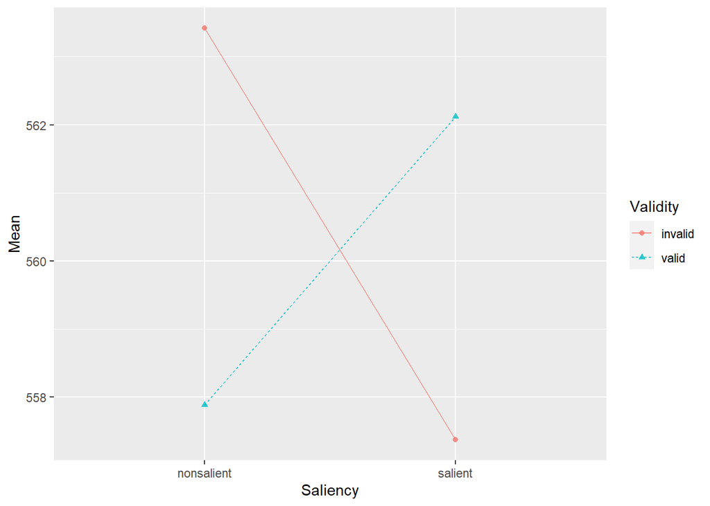

```r
ezPlot(data = wordWhitebg,
       dv = RT_ifo,
       wid = participant,
       within = .(Validity,Saliency),
       x = Saliency, split = Validity, do_bars = FALSE)
```

```r
##The pattern is reversed wherein the salient invalid trials are faster than salient valid trials and the opposite for non salient
```

This is the plot that shows the relationship between the words under each combination, only for participants with white background. Inspite of choosing the participants with the right assignment and coding of saliency, the initial pattern where one word pair had faster valid trials than the other still exists.

Interestingly you can see that it is faster for the word pair that is mapped to the right key “l”

Not sure if we can read so much into this but it is a consistent pattern across all combinations so it feels worthy to take note of.

- Perhaps we may have to check for effect of handedness or wonder whether while doing this study online participants only used one of their hands, instead of how we explain in the lab.

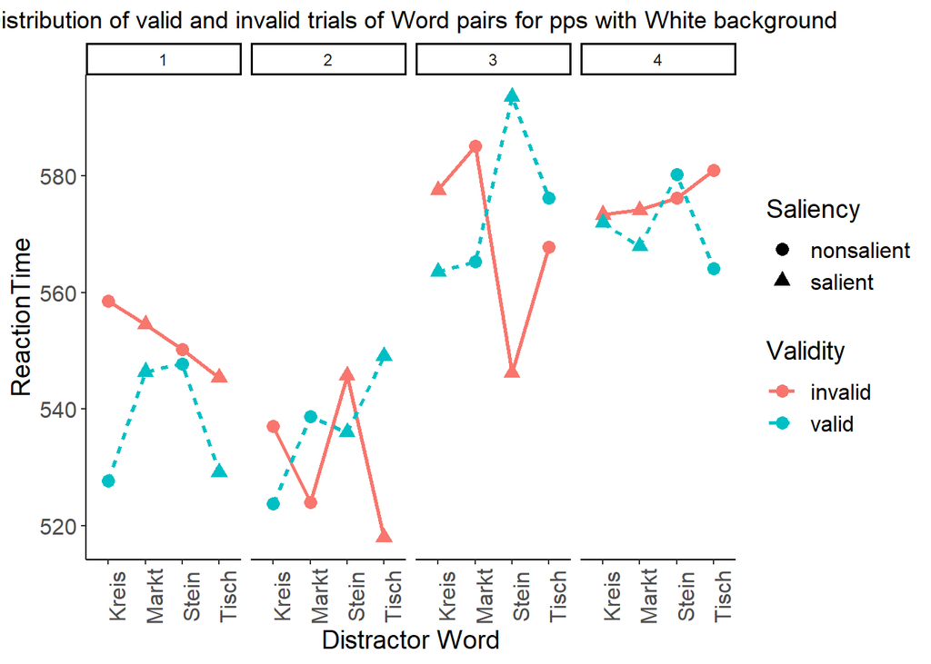

### Black Background

Conducted the same Analysis by choosing only participants with black background.The saliency factor was corrected by interchanging what was labelled as salient and nonsalient. However here there was no main effect or a significant interaction (as in the case for white bg), inspite of correcting for the salience factor assignment.

```r
###Same for Blackbackground

blackbg <- Exp1data_OL %>%
  subset(Screen_bg == "black")
table(blackbg$participant)
```

```
##
##   6   7  12  13 295 324 325 326 327 332 340 341 342 343 348 351 357 365
## 240 240 240 240 240 240 240 240 240 240 240 240 240 240 240 240 240 240
## 366 367 372 373 374 375 380 388 389 390 391 396 397 398
## 240 240 240 240 240 240 240 240 240 240 240 240 240 240
```

```r
blackbg <- blackbg%>%
  mutate(Saliency = ifelse(Saliency == "nonsalient", "Salient", "nonsalient"))


wordBlackbg <- aggregate(data=blackbg, RT_ifo~participant+Validity+Distractor1+Saliency+WordPair+CorrectAnswer, mean)


wordBlackbg$participant <- as.factor(wordBlackbg$participant)
wordBlackbg$Validity <- as.factor(wordBlackbg$Validity)
wordBlackbg$Distractor1 <- as.factor(wordBlackbg$Distractor1)
wordBlackbg$Saliency <- as.factor(wordBlackbg$Saliency)
wordBlackbg$WordPair <- as.factor(wordBlackbg$WordPair)
wordBlackbg$CorrectAnswer <- as.factor(wordBlackbg$CorrectAnswer)

Blackwordanova <- ezANOVA(data = wordBlackbg,
                     dv = RT_ifo,
                     wid = participant,
                     within = .(Validity, Saliency),
                     detailed = TRUE)
anova_out(Blackwordanova)
```

```
## $`--- ANOVA RESULTS     ------------------------------------`
##              Effect        MSE df1 df2       F     p petasq getasq
## 1       (Intercept) 27367.9982   1  31 1663.38 0.000   0.98   0.98
## 2          Validity   197.5547   1  31    0.04 0.850   0.00   0.00
## 3          Saliency   234.3711   1  31    0.01 0.918   0.00   0.00
## 4 Validity:Saliency   422.9008   1  31    0.02 0.889   0.00   0.00
##
## $`--- SPHERICITY TESTS  ------------------------------------`
## [1] "N/A"
##
## $`--- FORMATTED RESULTS ------------------------------------`
##              Effect                                    Text
## 1       (Intercept) F(1, 31) = 1663.38, p < .001, np2 = .98
## 2          Validity F(1, 31) =    0.04, p = .850, np2 < .01
## 3          Saliency F(1, 31) =    0.01, p = .918, np2 < .01
## 4 Validity:Saliency F(1, 31) =    0.02, p = .889, np2 < .01
##
## $`NOTE:`
## [1] "Reporting unadjusted p-values."
```

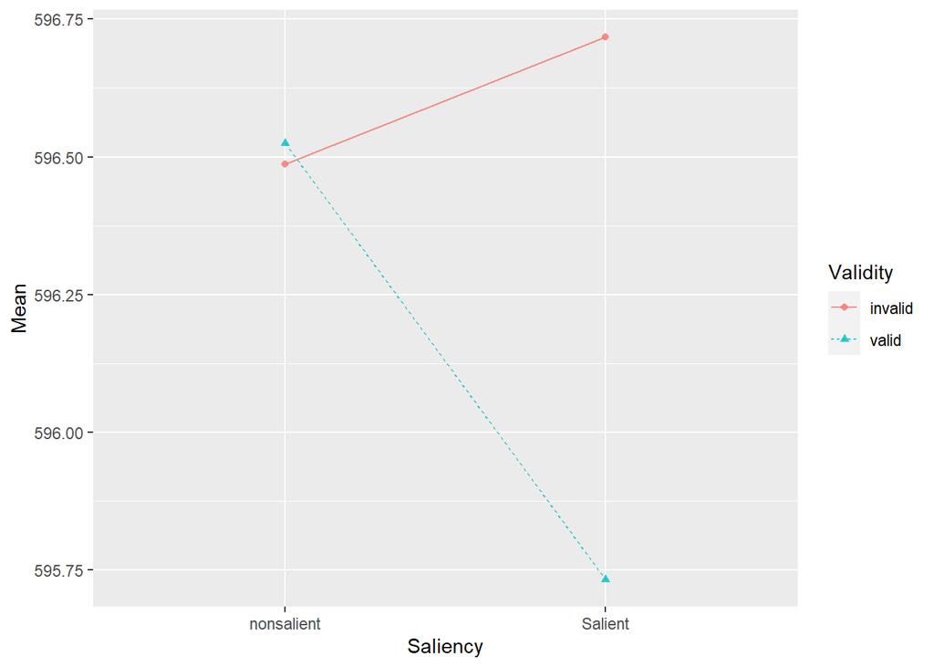

```r
ezPlot(data = wordBlackbg,
       dv = RT_ifo,
       wid = participant,
       within = .(Validity,Saliency),
       x = Saliency, split = Validity, do_bars = FALSE)
```

The pattern here looks different compared to the white bg, but the difference is really small to think of any contributing factors.

Now this is the plot showing the Validity effect for each of the Distractor words and still the same issue is visible inspite of correcting the salience factor. Similar to what was mentioned earlier, it is favourable towards the word pair associated with the Right key

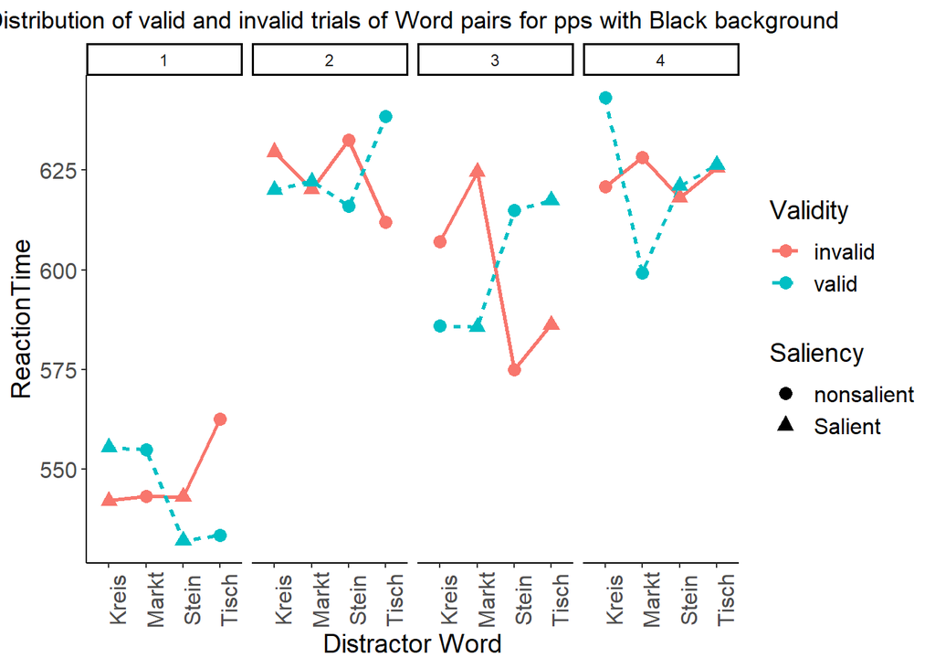